# Iris LDA

[Álvaro Rodríguez](https://github.com/AlvRodz) - 12 enero 2019

# Introducción

El análisis discriminante es una técnica estadística multivariante. La pertenencia de un individuo a uno u otro grupo se introduce en el análisis mediante una variable categórica, que toma tantos valores como grupos existentes. Esta será la varibale dependiente y sus diferentes valores sirven como etiqueta para cada observación. Las variables independientes o explicativas son continuas.Se pretende encontrar relaciones lineales entre las variables continuas que mejor discriminen en los grupos asignados a cada valor categórico.

Así pues, persigue explicar la pertenencia de cada individuo original a uno u otro grupo pre-establecido, en función de sus atributos, cuantificando el peso de cada uno de ellos en la discriminación. De esta manera, se puede predecir a qué grupo es más probable que perteneza una nueva observación, si conocemos sus respectivos valores explicativos.

El análisis discriminante está muy relacionado con el análisis multivariante de la varianza con un factor, aunque el papel que juegan los distintos tipos de variables está invertido en uno y otro método. Así, en el análisis de la varianza la variable categórica (el factor) es la variable explicativa, mientras que en el análisis discriminante la variable categórica es precisamente la variable dependiente.

# Datos

Para llevar a cabo el análisis se utilizan los datos del famoso dataset de **“Iris”**.

El conjunto de datos fue publicado originalmente en 1936 por el estadístico y biólogo británico, **Sir Ronald Fisher**, en su publicación “El uso de medidas múltiples en problemas taxonómicos”. Se trata de un conjunto de datos multivariante de **150 observaciones** con 4 atributos cada una: **longitud del sépalo, ancho del sépalo, longitud del pétalo y ancho del pétalo**. No hay valores nulos. Hay **50 observaciones de cada especie** de Iris (setosa, versicolor, virginica).

Entre los aspectos que resultan comúnmente apreciados se puede reseñar: **1)** El tamaño de su muestra (manejable pero aún significativo); **2)** Son datos reales, tomados por el botánico Edgar S. Anderson que recopiló los datos para cuantificar la variación morfológica de las flores de Iris de tres especies relacionadas. Dos de las tres especies fueron recolectadas en la Península de la Gaspesia, todas del mismo prado, recogidas en el mismo día y medidas al mismo tiempo por la misma persona con el mismo aparato; **3)** El uso de este conjunto de datos es una tradición. Al evaluar cualquier método, a menudo se considera útil probarlos en conjuntos de datos conocidos, manteniendo así cierta continuidad en la forma en que se evalúan los referidos métodos.

En cuanto al análisis discriminante lineal -aplicado originalmente por Sir Ronald Fisher a este conjunto de datos- la variable dependiente sería la especie de Iris y los atributos las variables explicativas.

Se muestra las primeras cinco observaciones completas del dataset.

```r
data(iris)
iris.5 <- iris[1:5,]
kable(iris.5, caption= "Iris dataset")
```

Iris dataset

| Sepal.Length | Sepal.Width | Petal.Length | Petal.Width | Species |
| --- | --- | --- | --- | --- |
| 5.1 | 3.5 | 1.4 | 0.2 | setosa |
| 4.9 | 3.0 | 1.4 | 0.2 | setosa |
| 4.7 | 3.2 | 1.3 | 0.2 | setosa |
| 4.6 | 3.1 | 1.5 | 0.2 | setosa |
| 5.0 | 3.6 | 1.4 | 0.2 | setosa |

# Análisis exploratorio de datos

## Distribución

Las variables explicativas, todas expresadas en centímetros, se distribuyen conforme se observa en la siguiente representación.

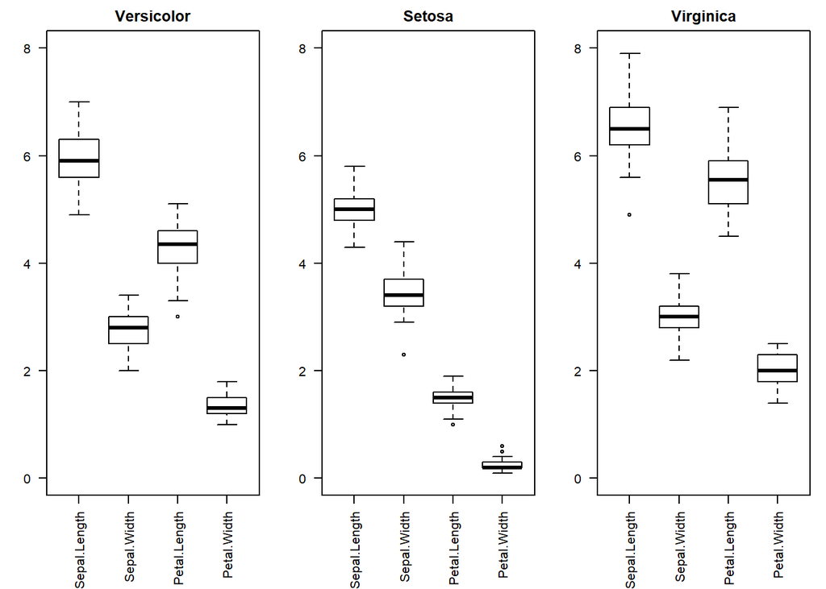

```r
# EDA
iris.ver <- subset(iris, Species == "versicolor")
iris.set <- subset(iris, Species == "setosa")
iris.vir <- subset(iris, Species == "virginica")
par(mfrow=c(1,3),mar=c(6,3,2,1))
boxplot(iris.ver[,1:4], main="Versicolor",ylim = c(0,8),las=2)
boxplot(iris.set[,1:4], main="Setosa",ylim = c(0,8),las=2)
boxplot(iris.vir[,1:4], main="Virginica",ylim = c(0,8),las=2)
```

La línea en negrita representa la mediana, la caja representa el Rango intercuantílico ((IQR = *Q*3 − *Q*1) de los valores muestrales de cada especie. Los límites inferiores y superiores, al final de cada línea discontínua, representan el valor mínimo/máximo (Excluyendo posibles outliers). Los posibles outliers aparecen representados como puntos, y son valores al menos 1,5 superiores al cuartil superior.

Aparentemente los valores de Versicolor y Virginica son más próximos entre sí, mientras que Setosa parece distribuirse de una forma significativamente distinta.

En términos generales, las variables parecen distribuirse de forma normal y simétrica.

## Correlación

Seguidamente, se muestra la matriz de correlaciones lineales de la variables explicativas.

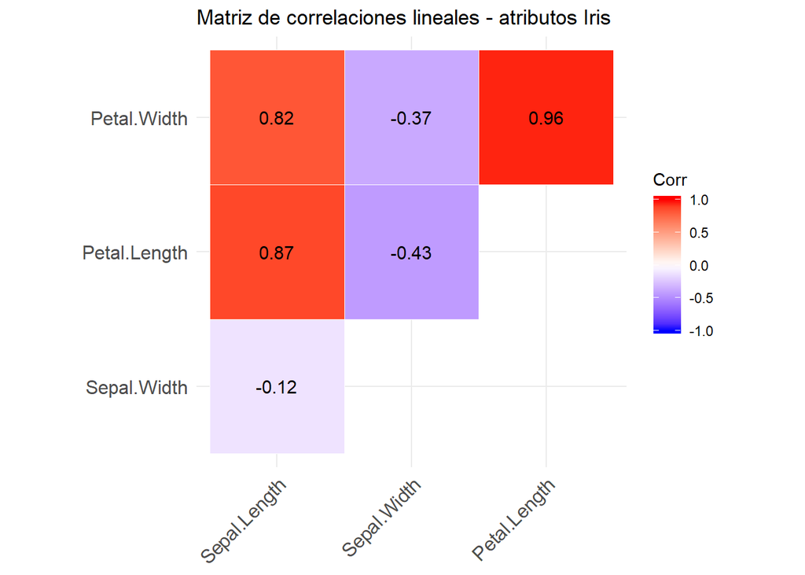

```r
# calculate correlations using cor and store the results
corr.iris <- cor(iris[,-5])

ggcorrplot(corr.iris,type = "upper",
     outline.col = "white", title = "Matriz de correlaciones lineales - atributos Iris",
     lab = TRUE)
```

Se puede interpretar que mientras la longitud y la anchura del pétalo están muy positivamente correlacionadas, la anchura y la longitud del sépalo apenas tienen correlación. Así, la longitud del sépalo está mucho más correlacionada con la longitud del pétalo y -necesariamente- con la anchura de este. Por último, la anchura del sépalo está correlacionada negativamente con los atributos del pétalo, pero no muy significativamente.

# Análisis Previo

Bajo las hipótesis que se enumeran a continuación, la función discriminante obtenida por el análisis discriminante es óptima:

- Cada uno de los grupos tiene una distribución normal multivariante: comprobamos con el test Shapiro-Wilks que las variables se distribuyen conforme a una normal.

```r
# Pruebas de normalidad

## Test de normalidad shapiro-Wilks para distribuciones multivariantes.
### H0: La población esta normalmente distribuida.

### 1) Virginica
iris.virginica <- as.matrix(iris[iris$Species == "virginica",1:4],ncol=4)

resultado_vir <- mvShapiro.Test(iris.virginica)

### se distribuye como una normal multivariante

### 2) setosa

iris.setosa <- as.matrix(iris[iris$Species == "setosa",1:4],ncol=4)

resultado_set <- mvShapiro.Test(iris.setosa)

### Se rechaza la hipótesis nula, no se distribuye como una normal multivariante.

### 3) versicolor

iris.versicolor <- as.matrix(iris[iris$Species == "versicolor",1:4],ncol=4)

resultado_ver <- mvShapiro.Test(iris.versicolor)

### se distribuye como una normal multivariante
```

Observamos que los atributos de las especies Virginica y Versicolor (sus respectivos p-valores son: 0.965 y 0.318) se distribuyen conforme a una normal multivariante. En cuanto a la especie setosa, el p-valor resultante del test Shapiro-Wilks (0.012) nos lleva a rechazar la hipótesis nula de normalidad.

- La matriz de covarianzas de todos los grupos es igual a *σ* (hipótesis de homocedasticidad). Si se tiene seguridad de que las muestras a comparar proceden de poblaciones que siguen una distribución normal, son recomendables el F-test y el test de Bartlet, pareciendo ser el segundo más recomendable ya que el primero es extremadamente sensible a desviaciones de la normal. Si no se tiene la seguridad de que las poblaciones de origen son normales, se recomiendan el test de Leven utilizando la mediana o el test no paramétrico Fligner-Killeen que también se basa en la mediana.

```r
# Test de Homocedasticidad


# F-distribution
res_F <- var.test(x = iris[iris$Species == "versicolor", "Petal.Length"],
         y = iris[iris$Species == "virginica", "Petal.Length"] )

## BoxM

## Test paramétrico que compara la varianza en muestras multivariantes. Comprueba si dos o más matrices de covarianzas son iguales (homogéneas)
## Ho: La matriz de covarianzas de las variables dependientes son iguales en todos los grupos/poblaciones
## H1: La matriz de covarianzas no es igual en todos los grupos

res_BoxM <- boxM(iris[, -5], iris[, 5])

### res


### summary(res)

## Barlett

## Ho: Todas las varianzas de una población k son iguales
## H1: La varianza de al menos dos poblaciones es diferente
# La prueba de Bartlett es sensible a las desviaciones de la normalidad. Es decir, si las muestras provienen de distribuciones
# no normales, entonces la prueba de Bartlett puede ser simplemente para probar la no normalidad

res_bar_1 <- bartlett.test(iris[,1]~Species, iris) # Sepal.length
res_bar_2 <- bartlett.test(iris[,2]~Species, iris) # Sepal.Width
res_bar_3 <- bartlett.test(iris[,3]~Species, iris) # Petal.Length
res_bar_4 <- bartlett.test(iris[,4]~Species, iris) # Petal.Width

## Barlett todas

res_bar_all <- bartlettTests(iris[,1:4], iris$Species) # Todas



## Levenne

##Prueba estadística inferencial utilizada para evaluar la igualdad de las varianzas para una variable calculada para dos o más grupos.
#Ho: las varianzas poblacionales son iguales
#H1: hay una diferencia entre las variaciones en la población.

res_levene_1 <- leveneTest(y = iris$Petal.Length, group = iris$Species, center = "median")
res_levene_2 <- leveneTest(y = iris$Petal.Width, group = iris$Species, center = "median")
res_levene_3 <- leveneTest(y = iris$Sepal.Length, group = iris$Species, center = "median")
res_levene_4 <- leveneTest(y = iris$Sepal.Width, group = iris$Species, center = "median")

res_levene_5 <- leveneTest(y = iris$Petal.Length, group = iris$Species, center = "mean")
res_levene_6 <- leveneTest(y = iris$Petal.Width, group = iris$Species, center = "mean")
res_levene_7 <- leveneTest(y = iris$Sepal.Length, group = iris$Species, center = "mean")
res_levene_8 <- leveneTest(y = iris$Sepal.Width, group = iris$Species, center = "mean")

# Test de Brown-Forsyth


res_BF <- hov(iris$Sepal.Length ~ iris$Species)

# p -value levene-sepal.width

p_1 <- round(res_levene_4$`Pr(>F)`[1],3)
p_2 <- round(res_levene_8$`Pr(>F)`[1],3)
```

En primer lugar en cuanto al **Test-M paramétrico de Box** de que compara la varianza en muestras multivariantes. Comprueba si dos o más matrices de covarianzas son iguales (homogéneas). En este caso se rechaza (p-valor: 3.352034210^{-20}) la hipótesis nula y se asume que la matriz de covarianzas de las variables dependientes no son iguales en todos los grupos/poblaciones.

A continuación se muestra la distintas funciones de densidad de cada especie por cada variable explicativa.

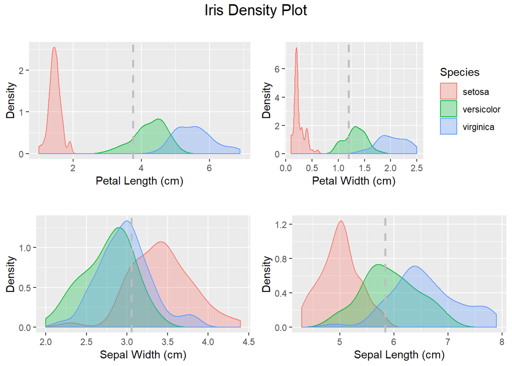

```r
D_Petal.Length <-    ggplot(iris, aes(x=Petal.Length, colour=Species, fill=Species)) +
  geom_density(alpha=.3) +
  geom_vline(aes(xintercept=mean(Petal.Length),  colour=Species),linetype="dashed",color="grey", size=1)+
  xlab("Petal Length (cm)") +
  ylab("Density")+
  theme(legend.position="none")

D_Petal.Width <- ggplot(iris, aes(x=Petal.Width, colour=Species, fill=Species)) +
  geom_density(alpha=.3) +
  geom_vline(aes(xintercept=mean(Petal.Width),  colour=Species),linetype="dashed",color="grey", size=1)+
  xlab("Petal Width (cm)") +
  ylab("Density")



D_Sepal.Width <- ggplot(iris, aes(x=Sepal.Width, colour=Species, fill=Species)) +
  geom_density(alpha=.3) +
  geom_vline(aes(xintercept=mean(Sepal.Width),  colour=Species), linetype="dashed",color="grey", size=1)+
  xlab("Sepal Width (cm)") +
  ylab("Density")+
  theme(legend.position="none")


D_Sepal.Length <- ggplot(iris, aes(x=Sepal.Length, colour=Species, fill=Species)) +
  geom_density(alpha=.3) +
  geom_vline(aes(xintercept=mean(Sepal.Length),  colour=Species),linetype="dashed", color="grey", size=1)+
  xlab("Sepal Length (cm)") +
  ylab("Density")+
  theme(legend.position="none")


# Plot all density visualizations
grid.arrange(D_Petal.Length + ggtitle(""),
             D_Petal.Width  + ggtitle(""),
             D_Sepal.Width + ggtitle(""),
             D_Sepal.Length  + ggtitle(""),
             nrow = 2,
             top = textGrob("Iris Density Plot",
                            gp=gpar(fontsize=15)))
```

# Análisis discriminante

El criterio de Fisher consiste en encontrar un vector de escalares de dimensión px1, de la forma: *α*´=*α*1, *α*2...*α**p* tal que el error de clasificación sea el mínimo posible o, lo que es lo mismo, maximice la distancia entre las medias proyectadas en relación con la variabilidad resultante en la proyección (variabilidad inter versus variabilidad intra).

Utilizamos la semilla “12345” para todos los procesos aleatorios.

## Modelo lineal

```r
# Predict

set.seed(12345)
training_sample <- sample(c(T,F),nrow(iris),replace = T,prob = c(0.65,0.35))
train <- iris[training_sample,]
test <- iris[!training_sample,]

# LDA

## re-train the model
set.seed(12345)
fit.LDA <- lda( Species ~ ., train)


df_1 <- as.data.frame(fit.LDA$scaling)

knitr::kable(df_1, caption = "Coeficientes del modelo discriminante lineal entrenado.")
```

Coeficientes del modelo discriminante lineal entrenado.

|  | LD1 | LD2 |
| --- | --- | --- |
| Sepal.Length | 1.022894 | 0.3279863 |
| Sepal.Width | 1.246732 | -2.2413639 |
| Petal.Length | -1.874228 | 0.9467081 |
| Petal.Width | -3.395647 | -3.2704578 |

El 98,84% del poder discriminatorio del modelo lo aporta el primer componente (LD1), mientras que el segundo componente (LD2) explica apenas un 1,16%.

Resulta evidente que el atributo con mayor capacidad discrimanante es **Petal.witdh**, su coeficiente (LD1: -3,39) es notablemente superior al resto de atributos.

Representamos las distintas especies en LD1 (que aporta la gran mayoría de la traza y por tanto del poder discriminante) y LD2, mediante un diagrama de puntos en el que se observa como setosa se distribuye muy diferenciadamente de las demás, mientras que la distancia entre las distribuciones de virginica y versicolor es considerablemente menor.

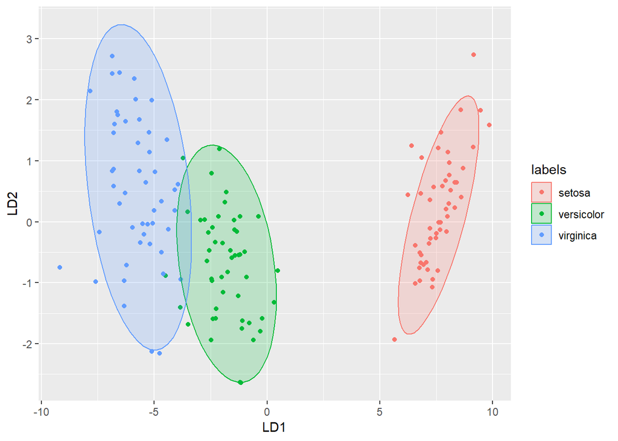

```r
## Viz


ggplotLDAPrep <- function(x){
  if (!is.null(Terms <- x$terms)) {
    data <- model.frame(x)
    X <- model.matrix(delete.response(Terms), data)
    g <- model.response(data)
    xint <- match("(Intercept)", colnames(X), nomatch = 0L)
    if (xint > 0L)
      X <- X[, -xint, drop = FALSE]
  }
  means <- colMeans(x$means)
  X <- scale(X, center = means, scale = FALSE) %*% x$scaling
  rtrn <- as.data.frame(cbind(X,labels=as.character(g)))
  rtrn <- data.frame(X,labels=as.character(g))
  return(rtrn)
}


test<-iris[grep("setosa|virginica|versicolor", iris$Species),1:5]
ldaobject <- lda(Species ~ ., data=test)
fitGraph <- ggplotLDAPrep(ldaobject)

ggplot(fitGraph, aes(LD1,LD2, color=labels))+
  geom_point() +
  stat_ellipse(aes(x=LD1, y=LD2, fill = labels), alpha = 0.2, geom = "polygon")
```

```r
##  testing

fit.LDA.C = predict(fit.LDA,test)

Conf_matrix <- confusionMatrix(fit.LDA.C$class,test[,5])

Pred_r1 <- as.data.frame(Conf_matrix$table)

Pred_r2 <- as.data.frame(Conf_matrix$overall)

kable(Pred_r1, caption = "Matriz de Confusión Modelo Lineal")
```

Matriz de Confusión Modelo Lineal

| Prediction | Reference | Freq |
| --- | --- | --- |
| setosa | setosa | 50 |
| versicolor | setosa | 0 |
| virginica | setosa | 0 |
| setosa | versicolor | 0 |
| versicolor | versicolor | 48 |
| virginica | versicolor | 2 |
| setosa | virginica | 0 |
| versicolor | virginica | 3 |
| virginica | virginica | 47 |

Asimismo, en cuanto a la **kappa de cohen**(más detalle en: https://stats.stackexchange.com/questions/82162/cohens-kappa-in-plain-english), también mostrada para complementar la métrica de accuracy, relaciona el accuracy obtenido con el accuracy esperado dado por el número de clases y su prevalencia. Los resultados son igualmente bastante notables.

```r
Pred_r2 <- as.data.frame(Pred_r2[-7,])

colnames(Pred_r2) <- "LDA Metrics"

kable(Pred_r2, caption = "Métricas del modelo lineal")
```

Métricas del modelo lineal

| LDA Metrics |
| --- |
| 0.9666667 |
| 0.9500000 |
| 0.9239277 |
| 0.9890898 |
| 0.3333333 |
| 0.0000000 |

## Modelo cuadrático

Llevamos a cabo el mismo procedimiento que anteriormente pero aplicando el análisis discriminante cuadrático en este caso. Las muestras de entrenamiento y test son las mismas que las anteriores.

Comparamnos nuevamente las previsiones del modelo con las referencias.

```r
# QDA
## re-train the model
set.seed(12345)
fit.QDA <- qda( Species ~ ., train)

df_qda <- as.data.frame(fit.QDA$scaling)
```

```
##  testing
```

```r
fit.QDA.C = predict(fit.QDA,test)


Conf_matrix_qda <- confusionMatrix(fit.QDA.C$class,test[,5])

Pred_r3 <- as.data.frame(Conf_matrix_qda$table)

Pred_r4 <- as.data.frame(Conf_matrix_qda$overall)

kable(Pred_r3, caption = "Matriz de Confusión Modelo cuadrático")
```

Matriz de Confusión Modelo cuadrático

| Prediction | Reference | Freq |
| --- | --- | --- |
| setosa | setosa | 50 |
| versicolor | setosa | 0 |
| virginica | setosa | 0 |
| setosa | versicolor | 0 |
| versicolor | versicolor | 48 |
| virginica | versicolor | 2 |
| setosa | virginica | 0 |
| versicolor | virginica | 1 |
| virginica | virginica | 49 |

El modelo cuadrático con las pruebas de entrenamiento y testing elegidas, tiene un **mayor accuracy** que el modelo anterior.

```r
Pred_r4 <- as.data.frame(Pred_r4[-7,])

colnames(Pred_r4) <- "LDA Metrics"

kable(Pred_r4, caption = "Métricas del modelo lineal")
```

| LDA Metrics |
| --- |
| 0.9800000 |
| 0.9700000 |
| 0.9426658 |
| 0.9958564 |
| 0.3333333 |
| 0.0000000 |

No obstante la diferencia entre los resultados de uno y otro modelo pudiera diferir si se hubieran seleccionado unas muestras distintas.

## Selección de modelo

La manera más conveniente de evaluar la calidad de los posibles modelos (lineal o cuadrático) que planteamos en este informe, es haciendo uso de la técnica de la Validación Cruzada o k-fold Cross Validation. Realizaremos la implementación de dicha técnica haciendo uso del paquete *caret* y evaluaremos el resultado de la misma.

Utilizaremos como métrica para la validación cruzada el denominado **accuracy** y **kappa** del modelo.

La 10 muestreos de entrenamiento (90%) y test(10%) se han llevado a cabo de forma aleatoria.

```r
# Cross validation

set.seed(12345)
control <- trainControl(method="cv", number=10, p= 0.90)
metric <- "Accuracy"

# Analysis

set.seed(12345)
fit.lda <- train(Species~., data=iris, method="lda", metric=metric, trControl=control)
# fit.lda
# fit.lda$finalModel


set.seed(12345)
fit.qda <- train(Species~., data=iris, method="qda", metric=metric, trControl=control)

#fit.qda
#fit.qda$finalModel

# select model

results <- resamples(list(lda=fit.lda, qda=fit.qda))

kable(results$values, caption = "Resultados de la validación cruzada de los métodos lineal y cuadrático")
```

Resultados de la validación cruzada de los métodos lineal y cuadrático

| Resample | lda~Accuracy | lda~Kappa | qda~Accuracy | qda~Kappa |
| --- | --- | --- | --- | --- |
| Fold01 | 1.0000000 | 1.0 | 1.0000000 | 1.0 |
| Fold02 | 1.0000000 | 1.0 | 1.0000000 | 1.0 |
| Fold03 | 0.9333333 | 0.9 | 0.9333333 | 0.9 |
| Fold04 | 0.9333333 | 0.9 | 0.9333333 | 0.9 |
| Fold05 | 1.0000000 | 1.0 | 1.0000000 | 1.0 |
| Fold06 | 1.0000000 | 1.0 | 1.0000000 | 1.0 |
| Fold07 | 1.0000000 | 1.0 | 1.0000000 | 1.0 |
| Fold08 | 0.9333333 | 0.9 | 0.9333333 | 0.9 |
| Fold09 | 1.0000000 | 1.0 | 1.0000000 | 1.0 |
| Fold10 | 1.0000000 | 1.0 | 1.0000000 | 1.0 |

Ambos análisis -lineal y cuadrático- obtienen los mismos resultados, ajustando con una precisión media del 98% en ambos casos y una kappa media del 97%.

# Referencias

- Template: https://github.com/holtzy/epuRate
- viz: https://www.kaggle.com/antoniolopez/iris-data-visualization-with-r

A work by [[Álvaro Rodríguez](https://github.com/AlvRodz)](https://github.com/AlvRodz)

*alvrodriguezprof@gmail.com*